# Chapter 6 In-Class R Demo: Nonstationarity and ARIMA

## Demo Goal

You will see why differencing turns some nonstationary series into stationary series.

Reference: random walk, differencing, ARIMA representation.

```r
set.seed(311)
par(mfrow = c(1, 1))
```

## 1. Random Walk

The recursion is $X_t = X_{t-1} + \epsilon_t$, starting at zero, so $\nabla X_t = X_t - X_{t-1} = \epsilon_t$. Predict which of the two ACF plots should look like white noise before running the chunk.

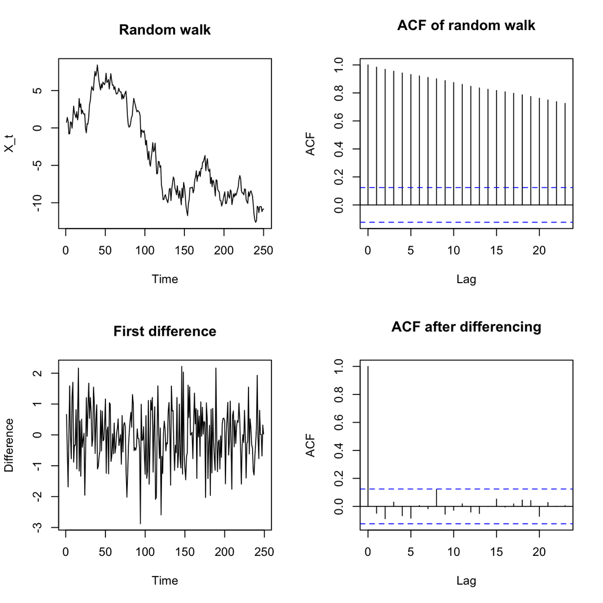

```r
n <- 250
x <- cumsum(rnorm(n))

par(mfrow = c(2, 2))
plot.ts(x, main = "Random walk", ylab = "X_t")
acf(x, main = "ACF of random walk")
plot.ts(diff(x), main = "First difference", ylab = "Difference")
acf(diff(x), main = "ACF after differencing")
```

```r
par(mfrow = c(1, 1))
```

Questions:

- Why does the sample ACF of the random walk start near 1 and decay almost linearly?
- Why does differencing help?

What the commands do:

- `rnorm(n)` generates independent normal increments with variance 1.
- `cumsum()` adds the increments to form a random walk.
- `diff(x)` subtracts each observation from the next; its length is `n - 1`.
- `acf()` here describes the observed sample. A nonstationary random walk has no stationary ACF depending on lag alone.

### Check the Difference Directly

```r
set.seed(311)
eps <- rnorm(250)
walk <- cumsum(eps)
max(abs(as.numeric(diff(walk)) - eps[-1]))
```

```
## [1] 8.881784e-16
```

`eps[-1]` omits the first increment because `diff()` has no preceding observed value for the first observation. The discrepancy should be close to zero, apart from numerical rounding.

## 2. Trend and Over-Differencing

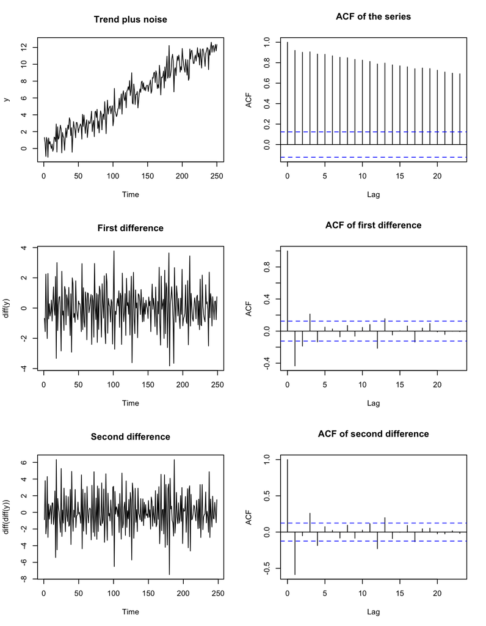

```r
t <- 1:n
y <- 0.05 * t + rnorm(n)

par(mfrow = c(3, 2))
plot.ts(y, main = "Trend plus noise")
acf(y, main = "ACF of the series")
plot.ts(diff(y), main = "First difference")
acf(diff(y), main = "ACF of first difference")
plot.ts(diff(diff(y)), main = "Second difference")
acf(diff(diff(y)), main = "ACF of second difference")
```

```r
par(mfrow = c(1, 1))
```

Questions:

- Is second differencing necessary?
- What visual warning appears when we over-difference? Look at the lag-1 autocorrelations and compare with $-1/2$ for $\nabla$ of white noise.
- Here the noise is iid around a linear trend: what does that say about the first difference, and what would be the alternative to differencing?

What the commands do:

- `0.05 * t` creates a deterministic linear trend, unlike the accumulated random shocks of Part 1.
- `diff(y)` removes the changing mean, but also differences the noise.
- `diff(diff(y))` differences an already stationary series in this example.

### Remove the Trend Without Differencing

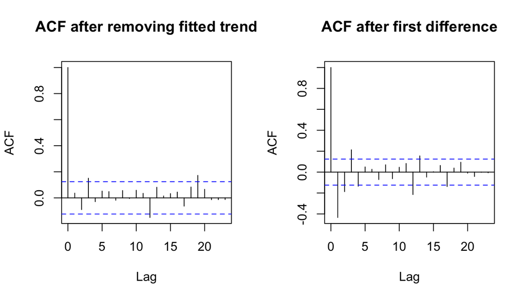

```r
trend_fit <- lm(y ~ t)
par(mfrow = c(1, 2))
acf(residuals(trend_fit), main = "ACF after removing fitted trend")
acf(diff(y), main = "ACF after first difference")
```

```r
par(mfrow = c(1, 1))
data.frame(
  series = c("Trend residuals", "First difference", "Second difference"),
  lag1_acf = round(c(acf(residuals(trend_fit), plot = FALSE)$acf[2],
                     acf(diff(y), plot = FALSE)$acf[2],
                     acf(diff(diff(y)), plot = FALSE)$acf[2]), 3)
)
```

```
##              series lag1_acf
## 1   Trend residuals    0.036
## 2  First difference   -0.434
## 3 Second difference   -0.586
```

Questions:

- Why does removing this fitted trend leave approximately independent noise?
- Why does differencing that noise create negative lag-1 correlation?
- Would fitting a straight line remove the accumulated shocks of a random walk?

Try it yourself:

- Set the trend slope to zero and rerun Part 2. Does first differencing help?

## 3. Simulate and Fit ARIMA

The model of the notes, $(1 - 0.5B)\nabla X_t = (1 - 0.4B)\epsilon_t$ ($\phi_1 = 0.5$, $\theta_1 = 0.4$), so R is given `ma = -0.4`.

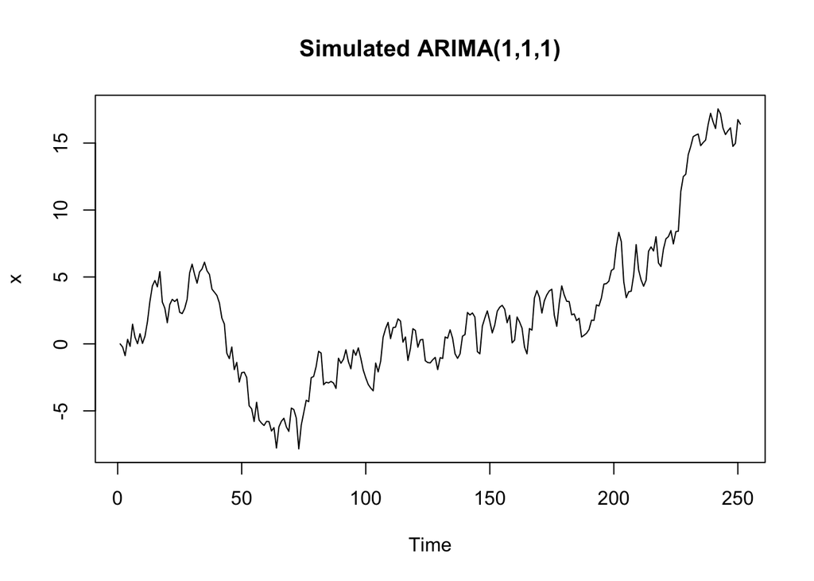

```r
x <- arima.sim(model = list(order = c(1, 1, 1), ar = 0.5, ma = -0.4), n = 250)
plot.ts(x, main = "Simulated ARIMA(1,1,1)")
```

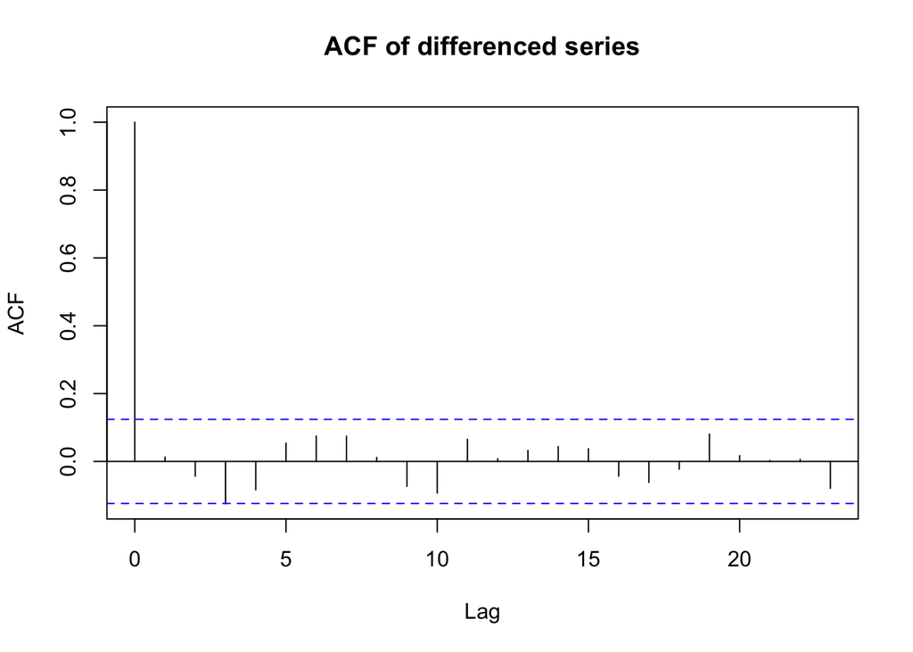

```r
acf(diff(x), main = "ACF of differenced series")
```

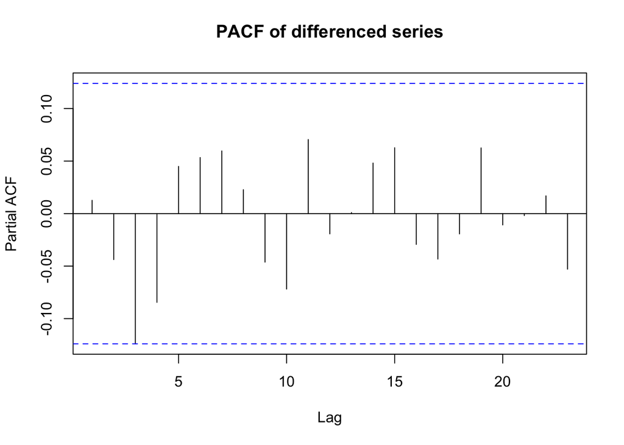

```r
pacf(diff(x), main = "PACF of differenced series")
```

```r
fit <- arima(x, order = c(1, 1, 1))
fit                                       # R's ma1 is -theta_hat
```

```
##
## Call:
## arima(x = x, order = c(1, 1, 1))
##
## Coefficients:
##           ar1     ma1
##       -0.1673  0.1873
## s.e.   1.1245  1.1189
##
## sigma^2 estimated as 1.018:  log likelihood = -356.98,  aic = 719.96
```

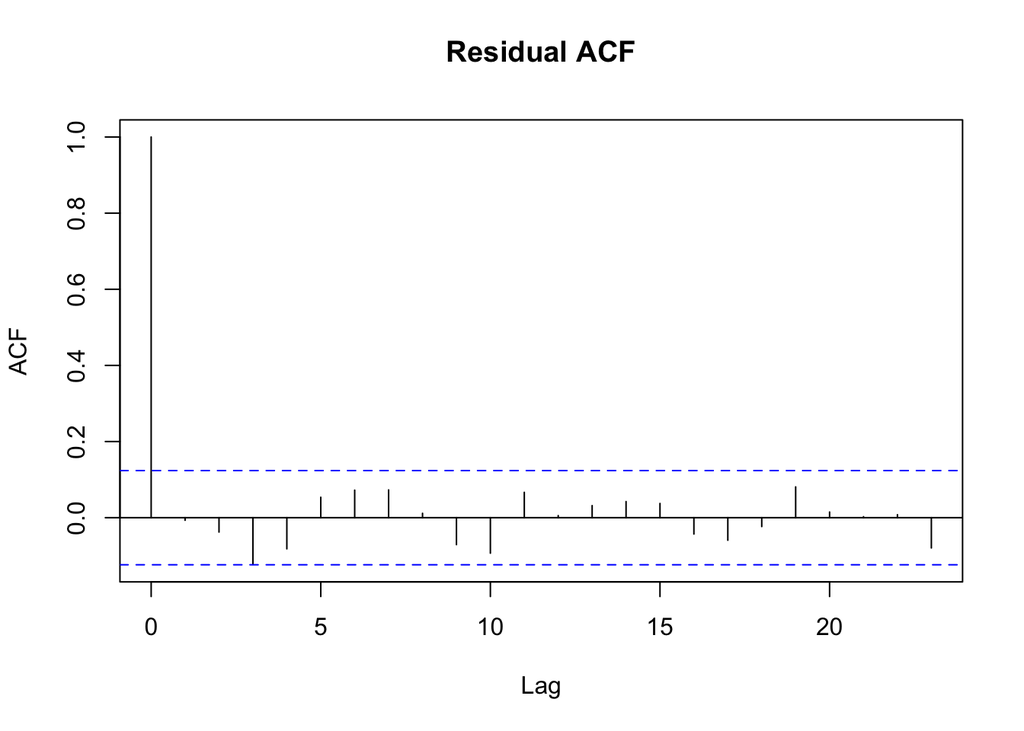

```r
acf(residuals(fit), main = "Residual ACF")
```

```r
Box.test(residuals(fit), lag = 12, type = "Ljung-Box", fitdf = 2)
```

```
##
##  Box-Ljung test
##
## data:  residuals(fit)
## X-squared = 14.29, df = 10, p-value = 0.1602
```

What the commands do:

- `order = c(1, 1, 1)` specifies an ARMA(1,1) for the first differences.
- `arima()` receives the undifferenced observations and applies `d = 1` internally. Do not also pass `diff(x)` with this same order.
- `fitdf = 2` counts the fitted AR and MA coefficients; it does not count the differencing order.

Questions:

- Compare `ar1` with $\phi_1 = 0.5$ and `-ma1` with $\theta_1 = 0.4$. Why are the estimates so imprecise? (Hint: $1 - 0.5B$ and $1 - 0.4B$ nearly cancel.)
- Do the residuals look like white noise?

For contrast, the same model with $\theta_1 = -0.4$ (`ma = 0.4`): the AR and MA factors $1 - 0.5B$ and $1 + 0.4B$ are now far apart.

```r
x2 <- arima.sim(model = list(order = c(1, 1, 1), ar = 0.5, ma = 0.4), n = 250)
fit2 <- arima(x2, order = c(1, 1, 1))
fit2                                      # R's ma1 is -theta_hat
```

```
##
## Call:
## arima(x = x2, order = c(1, 1, 1))
##
## Coefficients:
##          ar1     ma1
##       0.5436  0.3381
## s.e.  0.0689  0.0742
##
## sigma^2 estimated as 0.985:  log likelihood = -353.25,  aic = 712.5
```

```r
round(sqrt(diag(fit$var.coef)), 3)        # s.e., nearly cancelling factors
```

```
##   ar1   ma1
## 1.124 1.119
```

```r
round(sqrt(diag(fit2$var.coef)), 3)       # s.e., well-separated factors
```

```
##   ar1   ma1
## 0.069 0.074
```

- How much smaller are the standard errors when the factors are well separated? Which version is easier to identify from the ACF of `diff(x2)`?

Try it yourself:

- Increase the simulated length to `1000` in both chunks and rerun both fits.
- Compare the standard errors again. Are larger samples enough to make near cancellation easy to estimate?

## 4. Data: FTSE 100 Log-Returns

The notes difference the logarithm of the FTSE 100 index (`EuStockMarkets`, daily, 1991-1998).

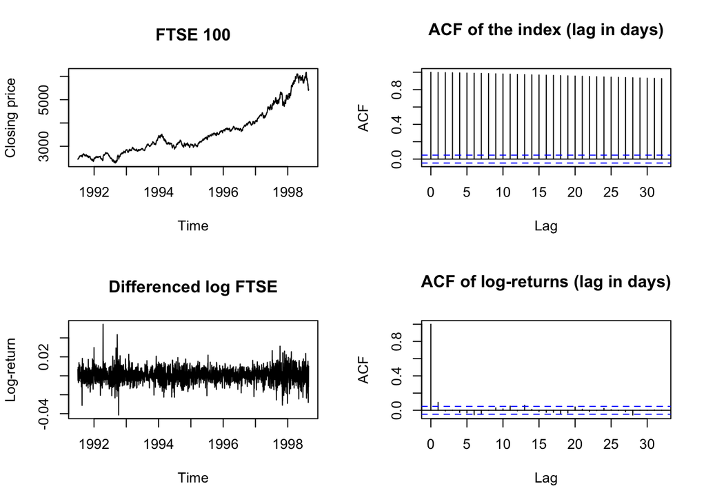

```r
ftse <- EuStockMarkets[, "FTSE"]
r <- diff(log(ftse))                     # log-returns

par(mfrow = c(2, 2))
plot(ftse, main = "FTSE 100", ylab = "Closing price")
acf(as.numeric(ftse), main = "ACF of the index (lag in days)")
plot(r, main = "Differenced log FTSE", ylab = "Log-return")
acf(as.numeric(r), main = "ACF of log-returns (lag in days)")
```

```r
par(mfrow = c(1, 1))
```

Questions:

- Which $d$ does the ACF of the index suggest?
- Is the mean of the log-returns constant? Is their variance?

What the commands do:

- `EuStockMarkets[, "FTSE"]` selects the FTSE column of the built-in data.
- `log()` turns ratios of prices into differences on the log scale.
- `diff(log(ftse))` gives log-returns, not ordinary percentage returns.
- `as.numeric()` makes the ACF horizontal axis count observations rather than fractions of a year.

Questions:

- Can an ACF alone establish that the variance is constant?
- Which periods in the return plot show unusually large fluctuations?

The plots suggest candidate differences; they do not establish stationarity by themselves. Check both the mean pattern and the size of the fluctuations.